# Bus Netowrk

Alan Tong

12/01/2024

# Introduction

> The equilibrium speed of car traffic on a road network is determined by the average door-to-door speed of equivalent journeys taken by public transport.

The Downs–Thomson paradox states that the speed of city traffic is limited by the speed of public transportation, usually in the form of the city bus. Honolulu ranks 18th in the US according to the INRIX’s annual global traffic scorecard for 2023. The last mile concept in urban design states that the dense city hubs grant the most expensive travel costs. This motivates me to investigate the Honolulu City and County bus networks in the perspective of cost to analyze what improvements could be made, which would decongest roads for both public and private transportation.

## Importing City Bus Network

The Oahu Transit Services company provides public data on bus routes and timetables in the form of a general transit feed specification (GTFS) file.

```r
BS_raw <- read_graph("networks/bus_network.graphml", format="graphml")
# Remove self-connections
BS <- simplify(subgraph_from_edges(BS_raw, which(E(BS_raw)$transportmode=="Bus"), delete.vertices = TRUE))
# Change weights to be estimate distance IRL calculating using longitude and latitude
edge_list <- as_edgelist(BS)
for(edge in E(BS)){
  vertex_ends <- edge_list[edge,]
  E(BS)$weight[edge] <- conv_unit(pointDistance(c(V(BS)$longitude[vertex_ends[1]],V(BS)$latitude[vertex_ends[1]]),c(V(BS)$longitude[vertex_ends[2]],V(BS)$latitude[vertex_ends[2]]), lonlat = TRUE),from ="m", to="mi")
}
summary(BS)
```

```
IGRAPH 3b13a1b D-W- 3755 4496 --
+ attr: label (v/c), r (v/n), g (v/n), b (v/n), x (v/n), y (v/n), size
| (v/n), latitude (v/n), longitude (v/n), id (v/c), weight (e/n)
```

This is the entire transit network operated by Oahu Transit Services. We would like to visualize only the bus network, and then arrange it geographically for visual clarity first.

```r
# Change the scale of the plot
scale <- 10

# Creating a layout for the plot according to longitude and latitude
location <- scale*matrix(c(V(BS)$longitude, V(BS)$latitude), ncol = 2)

# This below block of commented code produces a pdf of the plot

pdf("BusNetworkPlot.pdf",10,10)
plot(BS, vertex.label = NA, vertex.size = 2.5, edge.width = 0.1,  edge.arrow.size =0.1, layout = location, rescale=FALSE, asp=0, xlim = scale*range(V(BS)$longitude), ylim = scale*range(V(BS)$latitude))
dev.off()
```

```r
# Plot the network
plot(BS, vertex.label = NA, vertex.size = 2.5, edge.width = 0.1,  edge.arrow.size =0.1, layout = location, rescale=FALSE, asp=0, xlim = scale*range(V(BS)$longitude), ylim = scale*range(V(BS)$latitude))
```

[figure not shown]

With this visual, we can confirm that the GTSF data has been properly read, at least somewhat. We can also confirm that the weights have been changed to be a physical distance in miles, not accounting for road curvature.

## Hub Structure

Urban transit design often dictates that hubs are an essential part of a well functioning system. Focusing on a few transit hubs over the last mile neighborhoods often benefits more people due to denser housing in cities with higher demand for traffic. Does the Honolulu city bus network have the scale-free power structure we expect in a hub?

# Degree

```r
tibble("Top 10 Degrees" = top_n_vertices(BS,degree(BS))$label
)
```

| Top 10 Degrees |
| --- |
| VINEYARD BL + PALAMA ST |
| VINEYARD BL + PALAMA ST |
| KALIHI TRANSIT CENTER |
| S KING ST + PUNCHBOWL ST |
| KAMEHAMEHA HWY + OPP SALT LAKE BL |
| WAIANAE TRANSIT CENTER |
| HALAWA ALOHA STADIUM STATION |
| HICKAM AFB MAIN GATE |
| MEHEULA PKWY + KUAHELANI AVE |
| S BERETANIA ST + OPP KALAKAUA AVE |

# Parameters for Theoretical Predictions

```r
BS_degree <- degree(BS) # compute once for efficiency and convenience
tibble(
  "N = |V|" = vcount(BS),
  "M = |E|" = ecount(BS),
  "<k>" = mean(BS_degree),
  "ln N" = log(vcount(BS)),
  "ln N / ln <k>" = log(vcount(BS))/log(mean(BS_degree)),
  "ln ln N" = log(log(vcount(BS)))
)
```

| N = \|V\| | M = \|E\| | <k> | ln N | ln N / ln <k> | ln ln N |
| --- | --- | --- | --- | --- | --- |
| 3755 | 4496 | 2.394674 | 8.230844 | 9.425562 | 2.107889 |

# Prediction of random regime and connectivity

If this network was a random graph from $G(N,M)$, we would predict that it falls in the supercritical regime because $1 < \langle k\rangle < \ln{N}$. Therefore, we would expect the component structure to consist of a large primary network, and perhaps a small amount of smaller networks, disconnected from the primary network. This prediction has a basis reality, as the bus network is not perfect and could contain isolated routes.

# Construction of the random models

## $G(n,m)$ model

```r
BS_gnm <- sample_gnm(vcount(BS),ecount(BS))
BS_gnm$name <- paste("BS", BS_gnm$name)
summary(BS_gnm)
```

```
IGRAPH 3ec48f4 U--- 3755 4496 -- BS Erdos-Renyi (gnm) graph
+ attr: name (g/c), type (g/c), loops (g/l), m (g/n)
```

## Configuration model

```r
BS_config <- sample_degseq(BS_degree, method="configuration")
BS_config$name <- paste("BS", BS_config$name)
summary(BS_config)
```

```
IGRAPH 3ec74bd U--- 3755 4496 -- BS Degree sequence random graph
+ attr: name (g/c), method (g/c)
```

## Degree perserving randomization

```r
BS_rewire <- rewire(BS, with=keeping_degseq(niter=ecount(BS)*100))
BS_rewire$name <- "Bus Network Rewired"
summary(BS_rewire)
```

```
IGRAPH 3ed1995 D-W- 3755 4496 -- Bus Network Rewired
+ attr: name (g/c), label (v/c), r (v/n), g (v/n), b (v/n), x (v/n), y
| (v/n), size (v/n), latitude (v/n), longitude (v/n), id (v/c), weight
| (e/n)
```

## Scalar Network Metrics

```r
BS_models <- list(BS, BS_gnm, BS_config, BS_rewire) # must list not c
percent_giant <- function(graph) vcount(largest_component(graph))/vcount(graph)
tibble(
  Model         = c("Bus Network", "G(n,m)", "Config", "Rewire"),
  components    = sapply(BS_models,count_components), # Number of components
  percent_giant = sapply(BS_models,percent_giant), # Percent in giant component
  meandist      = sapply(BS_models,mean_distance), # Mean distance
  transitivity  = sapply(BS_models, transitivity, type="global"), # Global transitivity
  degreeassort  = sapply(BS_models, assortativity_degree)  # Degree assortativity
)
```

| Model | components | percent_giant | meandist | transitivity | degreeassort |
| --- | --- | --- | --- | --- | --- |
| Bus Network | 1 | 1.0000000 | 20.81271 | 0.0425131678 | 0.3178925074 |
| G(n,m) | 387 | 0.8748336 | 9.03293 | 0.0008347245 | 0.0008418033 |
| Config | 2 | 0.9997337 | 13.18916 | 0.0007525398 | 0.0173395649 |
| Rewire | 1 | 1.0000000 | 30.07495 | 0.0003762227 | -0.0021803571 |

# Comparison to Theoretical Predictions

## Connectivity:

The values of $\langle k \rangle$ and $\ln{N}$ leads one to assume that the a if the bus network were a randomly generated network, is likely to have been a large component along with a few small components. As we calculate in the table above, the natural bus network is a single connected component, which contradicts this calculation. This suggests that the Erdős-Rényi model deviates from the meticulously engineered bus network.

# Comparison to Random Models

## Mean Distance

The mean unweighted distance of the natural bus network is 20.812711. This distance is distinct from any of the graph models. This tells us that the distance is a unique property of the natural bus network, and not a property of the degree distribution or generic networks of that size. This makes sense, as the bus network is a complex transit system, inheriting the topology of the a locally euclidean space, with the intent of moving people.

## Transitivity

The transitivity of the natural bus network is higher than the transitivity of the random networks. This demonstrates that the transitivity structure of the natural bus network is not granted by the size or degree distribution. This is validated by how the bus should have a higher transitivity than a generic network, since transitivity within the city is expected to be much higher, allowing passengers to get as close to their stop as possible by transfering busses.

## Degree Assortativity

The assortativity of the natural bus network is significantly larger than that of the randomly generated models. Assortativity correlates to the freqency for nodes of the same degree connect. This value is lower in the randomly generated models that, while perserving degree, do not perserve the structure of a bus route. Bus stops are of high degree in the dense city, and will frequently connect to each other. Low degree bus stops in rural areas will mostly connect with similar bus stops. These degrees will mix at the suburbs more frequently, lowering assortativity.

# Bus Network Degree Distribution

## Degree Distribution Plots

```r
# Plot the degree distribution of the natural network on log-log axes
# using linear binning (the default). Use the degree domain adjustment,
# and provide appropriate labels. Add a legend topright showing k-min,
# mean degree <k>, centralized second moment <k^2> and maximum degree
# k-max. You may use the moments package for <k^2>, or just write the
# formula yourself based on the readings.
plot(degree_domain(BS), degree_distribution(BS),
     main = 'Bus Natural Graph',
     log = "xy", xlab = "k", ylab = "p(k)")

legend("topright",legend=c(c("k-min = ", min(degree_distribution(BS))),
                  c("<k> = ", moment(degree_distribution(BS),1)),
                  c("<k^2> = ", moment(degree_distribution(BS),2)))
              ,plot=T,bty="n")
```

[figure not shown]

```r
# Now plot the CUMULATIVE degree distribution of the natural network on
# log-log axes. Use the degree domain adjustment, and provide
# appropriate labels. This plot need not have a legend.
plot(degree_domain(BS), degree_distribution(BS, cumulative = TRUE),
     main = 'Bus Natural Cumulative Graph',
     log = "xy", xlab = "k", ylab = "CDF p(k)")
```

[figure not shown]

## Fit to Power-law

```r
as_tibble(fit_power_law(degree(BS),
                        implementation = "plfit",
                        p.value = TRUE)[2:6])
```

| alpha | xmin | logLik | KS.stat | KS.p |
| --- | --- | --- | --- | --- |
| 4.116703 | 2 | -3041.723 | 0.01239382 | 0 |

# Centrality

```r
V(BS)$strength <- strength(BS)
V(BS)$page_rank_w <- page_rank(BS)$vector
V(BS)$between_w <- betweenness(BS,weights = E(BS)$weight, normalized = TRUE)
V(BS)$harmonic_w  <- harmonic_centrality(BS, weights = E(BS)$weight, normalized = TRUE)
tibble(
  WeightedDegree = top_n_vertices(BS,V(BS)$strength,n=10)$label, # Degree
  WeightedPageRank = top_n_vertices(BS,V(BS)$page_rank_w,n=10)$label, # Usefulness by neighborhood around it
  WeightedHarmonicCentrality = top_n_vertices(BS,V(BS)$harmonic_w,n=10)$label, # Has the most reach to the rest of the network
  WeightedBetweenness = top_n_vertices(BS,V(BS)$between_w,n=10)$label, # Crossed the most
)
```

| WeightedDegree | WeightedPageRank | WeightedHarmonicCentrality | WeightedBetweenness |
| --- | --- | --- | --- |
| VINEYARD BL + PALAMA ST | S KING ST + PUNCHBOWL ST | BISHOP ST + S HOTEL ST | VINEYARD BL + LILIHA ST |
| VINEYARD BL + PALAMA ST | VINEYARD BL + PALAMA ST | PALI HWY + S BERETANIA ST | VINEYARD BL + PALAMA ST |
| HICKAM AFB MAIN GATE | BISHOP ST + S HOTEL ST | BISHOP ST + S KING ST | S KING ST + PUNCHBOWL ST |
| AINAMAKUA DR + MEHEULA PKWY | VINEYARD BL + PUA LN | S BERETANIA ST + ETERNAL FLAME | BISHOP ST + S HOTEL ST |
| KAPAHULU AVE + CAMPBELL AVE | VINEYARD BL + LILIHA ST | S KING ST + BETHEL ST | S BERETANIA ST + PUNCHBOWL ST |
| KAMEHAMEHA HWY + OPP SALT LAKE BL | KALIHI TRANSIT CENTER | S KING ST + PUNCHBOWL ST | KALIHI TRANSIT CENTER |
| LIKELIKE HWY + SCHOOL ST | PALI HWY + S BERETANIA ST | ALAPAI TRANSIT CENTER (STOPS 1-4) | N BERETANIA ST + OPP SMITH ST |
| AINAMAKUA DR + MEHEULA PKWY | N KING ST + N BERETANIA ST | ALAPAI TRANSIT CENTER (UNLOADING) | S BERETANIA ST + PALI HWY + BISHOP ST |
| PAIWA ST + HIAPO ST | S BERETANIA ST + PUNCHBOWL ST | KONA ST + OPP KONA IKI ST (NS) | PALI HWY + S BERETANIA ST |
| ALA MOANA BL + HOBRON LN | N KING ST + MAUNAKEA ST | KAPIOLANI BL + SOUTH ST | N BERETANIA ST + OPP RIVER ST |

# Community Detection

Community detection is a rapidly growing network science. It demonstrates a general capability in analysis of networks, especially in social networks. The Oahu bus transit system may be considered to be a social network, as it is developed to move people. In this section, we investigate the capability of a community detection algorithm to segregate the different districts of Oahu. There are nine districts defined in the charter of the City and County of Honolulu.

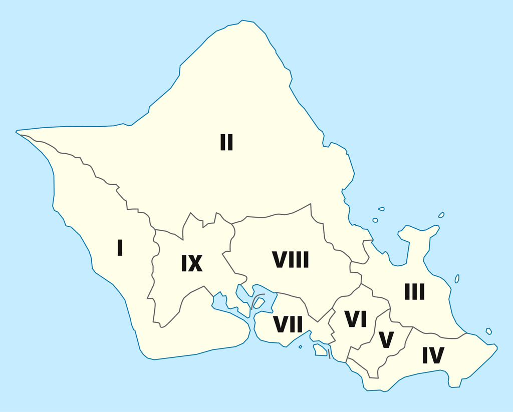

```r
include_graphics("images/Honolulu_County_districts.png")
```

```r
tibble(
  "1" = "Waianae",
  "2" = "Wahiawa and North Shore",
  "3" = "Kailua",
  "4" = "Hawai'i Kai",
  "5" = "Manoa Valley",
  "6" = "Downtown Honolulu",
  "7" = "Kalihi",
  "8" = "Pearl City",
  "9" = "Kapolei"
)
```

| 1 | 2 | 3 | 4 | 5 | 6 | 7 | 8 | 9 |
| --- | --- | --- | --- | --- | --- | --- | --- | --- |
| Waianae | Wahiawa and North Shore | Kailua | Hawai'i Kai | Manoa Valley | Downtown Honolulu | Kalihi | Pearl City | Kapolei |

```r
BS_u <- as_undirected(BS, mode = "collapse")
BS_comm <- cluster_leiden(BS_u, resolution = 0.000004)
V(BS)$membership <- membership(BS_comm)
write_graph(BS, "bus_network_simplified_springlass.graphml", format="graphml")
largest_community_id <- which.max(sizes(BS_comm))
largest_community <- induced.subgraph(BS_u, which(membership(BS_comm) == largest_community_id))
tibble(
  "Amount of Communities" = length(communities(BS_comm)),
  "Size of Largest Community" = length(V(largest_community))
)
```

| Amount of Communities | Size of Largest Community |
| --- | --- |
| 10 | 1623 |

```r
plot(BS_comm, BS_u, vertex.label = NA, vertex.size = 2.5, edge.width = 0.1,  edge.arrow.size =0.1, layout = location, rescale=FALSE, asp=0, xlim = scale*range(V(BS_u)$longitude), ylim = scale*range(V(BS_u)$latitude))
```

[figure not shown]

```r
# pdf("BusNetworkCommunityPlot.pdf",10,10)
# plot(BS_comm, BS, vertex.label = NA, vertex.size = 2.5, edge.width = 0.1,  edge.arrow.size =0.1, layout = location, rescale=FALSE, asp=0, xlim = scale*range(V(BS)$longitude), ylim = scale*range(V(BS)$latitude))
# dev.off()
```

An additional functioning community detection algorithm is label propagation. It is shown below for demonstration that the second best community detection for this geographic problem fails to approximate the districts of Oahu. Hence the discussion continues with only Leiden community detection.

```r
BS_comm2 <- cluster_label_prop(BS, mode="out")
V(BS)$membership <- membership(BS_comm2)
write_graph(BS, "bus_network_simplified_springlass.graphml", format="graphml")
largest_community_id <- which.max(sizes(BS_comm2))
largest_community <- induced.subgraph(BS, which(membership(BS_comm2) == largest_community_id))
tibble(
  "Amount of Communities" = length(communities(BS_comm2)),
  "Size of Largest Community" = length(V(largest_community))
)
```

| Amount of Communities | Size of Largest Community |
| --- | --- |
| 5 | 3160 |

```r
plot(BS_comm2, BS, vertex.label = NA, vertex.size = 2.5, edge.width = 0.1,  edge.arrow.size =0.1, layout = location, rescale=FALSE, asp=0, xlim = scale*range(V(BS)$longitude), ylim = scale*range(V(BS)$latitude))
```

[figure not shown]

The Leiden communities demonstrates a stark difference from the legislative communities that rule Oahu. District one is shrunken to strictly Waianae; district two carries with it two communities; district three and district four are blended together; district five and six are well mixed together; district six, seven, and eight seem to maintain themselves separately; district nine spans now central Oahu and a neighborhood outside of it.

This community detection allows us to highlight the communities as seen by the bus transit system. The communities highlight an important fact of bus travel: communities are easy to travel within, but difficult to travel between. Relevant to Oahu, rural areas of Oahu (districts one, two, three, and four) follow this rule, which the community detection has also determined. The urban parts of Oahu (districts five, six, and seven) have their own communities with some overlap over each other. The suburbs perfects intersect with the rural and urban parts Oahu according to the communities.

Analysis of communities through the lens of transit systems is an effective way of loosely partitioning a state. Society functions through movement; the movement of people can be recognized as the routes of public transportation, so community detection of bus transit networks describes districts in terms of movement. This technique is validated by the rural, suburb, and urban detection on Oahu.

# Fiedler Vector

The Fiedler vector is a result by Miroslav Fielder in 1972. In his paper *Algebraic Connectivity of Graphs*, he expands on the normal spectral analysis done to the adjacency matrix $A$ of a graph $G$ to instead be done on the graph Laplacian $L:= D-A$, where $D$ is the degree matrix that sums all the weight of all connecting edges; alternatively, sums the row or column of the vertex in the adjacency matrix. Recall that the adjacency matrix of a graph $G$ is $(A(G))_{(i,j)} := w_{i,j}$ where $w_{i,j}$ is the weight of the edge from vertex $i$ to $j$, set to 0 if there is no edge. This extends to unweighted graphs by setting $w_{i,j} = \delta_{i,j}\in\{0,1\}$.

## Analysis with Fielder Vector

```r
as_weight_matrix <- function(NW){
  NW[]
}
as_degree_matrix <- function(NW){
  n <- length(V(NW))
  WNW <- as_weight_matrix(NW)
  A <- matrix(0, n, n)
  for (i in (1:n)){
    A[i,i] <- sum(WNW[,i])
  }
  A
}

BS_adj <- as_weight_matrix(BS)
BS_deg <- as_degree_matrix(BS)
BS_lap <- BS_deg - BS_adj
BS_eigen <- eigen(BS_lap)
```

```r
k <- 2
BS_fiedv <- BS_eigen$vectors[,length(V(BS))-k]
BS_fiedn <- BS_eigen$values[length(V(BS))-k]
normalized_BS_fiedv<- Re(BS_fiedv)/max(Re(BS_fiedv))
tibble(
  "Fiedler Vector" = Re(BS_fiedv),
  "Normalized Fiedler Vector" = normalized_BS_fiedv,
  "Fielder Number" = Re(BS_fiedn)
)
```

| Fiedler Vector | Normalized Fiedler Vector | Fielder Number |
| --- | --- | --- |
| -1.652388e-03 | -5.786930e-03 | 0.001447549 |
| -2.694039e-03 | -9.434962e-03 | 0.001447549 |
| -1.955368e-03 | -6.848018e-03 | 0.001447549 |
| -3.401493e-03 | -1.191258e-02 | 0.001447549 |
| -1.882031e-03 | -6.591180e-03 | 0.001447549 |
| -1.124710e-02 | -3.938919e-02 | 0.001447549 |
| -1.000679e-02 | -3.504542e-02 | 0.001447549 |
| -9.453730e-03 | -3.310850e-02 | 0.001447549 |
| -6.462336e-03 | -2.263215e-02 | 0.001447549 |
| -1.291162e-03 | -4.521859e-03 | 0.001447549 |

[output cut: 3745 more lines]

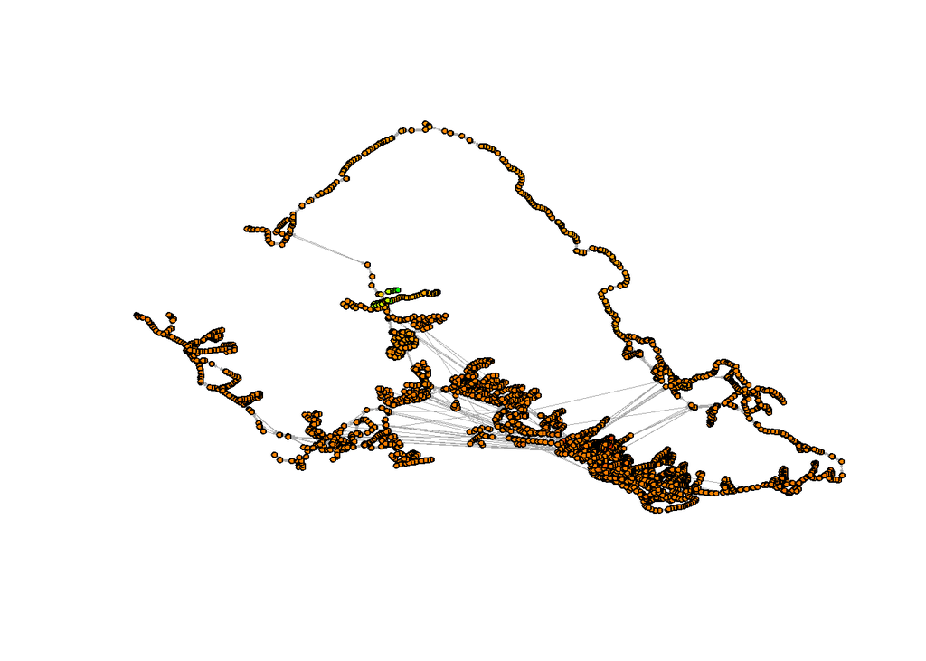

```r
color.gradient <- function(x, colors=c("red", "yellow", "green"),
                           colsteps=100) {
  return(colorRampPalette(colors)(colsteps)[
    findInterval(x, seq(min(x), max(x), length.out=colsteps))
  ])
}

plot(BS, vertex.label = NA, vertex.size = 5, edge.width = 0.1,  edge.arrow.size =0.1, layout = location, rescale=FALSE, asp=0, xlim = scale*range(V(BS)$longitude), ylim = scale*range(V(BS)$latitude), vertex.color = color.gradient(normalized_BS_fiedv))
```